Dear friend,

I hope to alert you how bad the COVID-19 in **Singapore** is by comparing it with **Wuhan**.

# 0. Summary

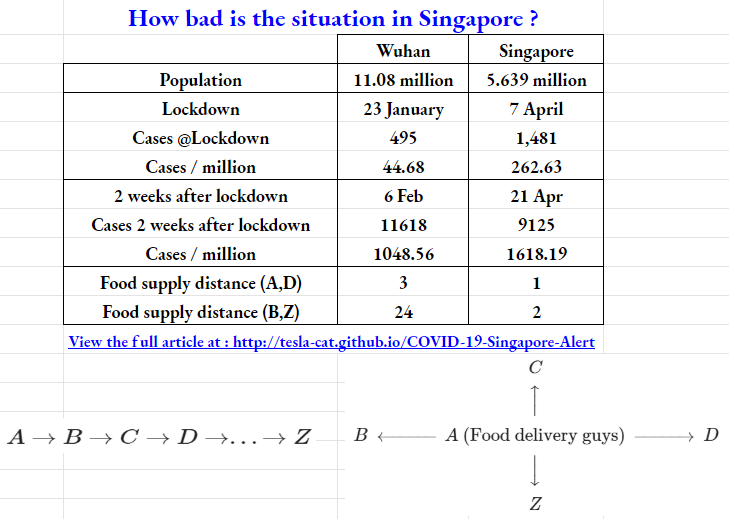

# 1. Number cases per million people as of lockdown

The population of Wuhan is $$\text{11.08 million -Wuhan}$$ (2018, by Google), the lockdown in Wuhan took place on $$\text{23 January -Wuhan}$$ (by Google). At that time the total number of cases in Wuhan was $$\text{495 -Wuhan}$$ and the cases per million people for Wuhan is $${495 \over 11.08} = 44.68 \; {\text{cases}\over \text{million}} \text{ -Wuhan}$$

The population of Singapore is $$\text{5.639 million -Singapore}$$ (2018, by Google), the lockdown in Singapore took place on $$\text{7 April -Singapore}$$. At that time the total number of cases in Singapore was $$\text{1,481 -Singapore}$$ (by Wikipedia). Thus the cases per million people Wuhan would be $${1481 \over 5.639} = 262.63 \; {\text{cases}\over \text{million}} \text{ -Singapore}$$

# 2. Strength of lockdown

Now if you check news or whatever, then lockdown measures in Singapore are way weaker than that of Wuhan.

- In Wuhan people are forbidden to leave their homes. Food and other daily necessities are distributed by authorities in order to achieve minimum contact. I.e. The pattern is strictly $$A \to B \to C \to D\to ...\to Z$$, there are 2 barriers between $A$ and $D$ $$\text{dist}(A,D)=3$$. And 23 between $B$ and $Z$ $$\text{dist}(B,Z)=24$$
- In Singapore the lockdown merely means no more working in public areas. But people are allowed to go anywhere. I see a lot of people still jogging around not wearing any mask as if they are invincible. And most importantly: **Food delivery guys** run around everywhere, they are the **most dangerous media** of spreading the virus. The contact is $$\require{AMScd} \begin{CD} @. C \\ @. @AAA \\ B @<<< A \text{ (Food delivery guys)} @>>> D\\ @. @VVV \\ @. Z \end{CD}$$ , there are 0 barriers between $A$ and $D$ $$\text{dist}(A,D)=1$$. And 1 between $B$ and $Z$ $$\text{dist}(B,Z)=2$$

# 3. The effect of lockdown after $2$ weeks

$2$ weeks after the lockdown ($6 \text{ Feb}$) the total number of cases in Wuhan was $$\text{11618 -Wuhan}$$ and the cases per million people for Wuhan would be $${11618 \over 11.08} = 1048.56 \; {\text{cases}\over \text{million}} \text{ -Wuhan}$$

$2$ weeks after the lockdown ($21 \text{ Apr}$) the total number of cases in Singapore was $$\text{9125 -Singapore}$$ and the cases per million people for Singapore would be $${9125 \over 5.639} = 1618.19 \; {\text{cases}\over \text{million}} \text{ -Singapore}$$

Best regards, Ruiqi.